# R Notebook

В цій лабораторній роботі побудуємо за даними детектора гравітаційних волн LIGO графік злиття двох нейтронних зір. Подія GW170817 https://uk.wikipedia.org/wiki/GW170817. Лабораторну роботу створено на основі https://losc.ligo.org/tutorial00/ 1. Завантажте файл з даними за посиланням https://dcc.ligo.org/public/0146/P1700337/001/H-H1_LOSC_C00_4_V1- 1187006834-4096.hdf5 2. Встановить в R пакет для роботи з HDF5 файлами. 3. Виведіть зміст файлу командою h5ls().

```r
library(rhdf5)
h5ls('D:/Education/6.1/R/H-H1_LOSC_C00_4_V1-1187006834-4096.hdf5',all=TRUE)
```

|  | group | name | ltype | cset | otype | num_attrs | dclass | dtype | stype | rank | dim | maxdim |
| --- | --- | --- | --- | --- | --- | --- | --- | --- | --- | --- | --- | --- |
| 0 | / | meta | H5L_TYPE_HARD | 0 | H5I_GROUP | 0 |  |  |  | 0 |  |  |
| 1 | /meta | Description | H5L_TYPE_HARD | 0 | H5I_DATASET | 0 | STRING | H5T_STRING | SCALAR | 0 | ( 0 ) | ( 0 ) |
| 2 | /meta | DescriptionURL | H5L_TYPE_HARD | 0 | H5I_DATASET | 0 | STRING | H5T_STRING | SCALAR | 0 | ( 0 ) | ( 0 ) |
| 3 | /meta | Detector | H5L_TYPE_HARD | 0 | H5I_DATASET | 0 | STRING | H5T_STRING | SCALAR | 0 | ( 0 ) | ( 0 ) |
| 4 | /meta | Duration | H5L_TYPE_HARD | 0 | H5I_DATASET | 0 | INTEGER | H5T_STD_I64LE | SCALAR | 0 | ( 0 ) | ( 0 ) |
| 5 | /meta | GPSstart | H5L_TYPE_HARD | 0 | H5I_DATASET | 0 | INTEGER | H5T_STD_I64LE | SCALAR | 0 | ( 0 ) | ( 0 ) |
| 6 | /meta | Observatory | H5L_TYPE_HARD | 0 | H5I_DATASET | 0 | STRING | H5T_STRING | SCALAR | 0 | ( 0 ) | ( 0 ) |
| 7 | /meta | Type | H5L_TYPE_HARD | 0 | H5I_DATASET | 0 | STRING | H5T_STRING | SCALAR | 0 | ( 0 ) | ( 0 ) |
| 8 | /meta | UTCstart | H5L_TYPE_HARD | 0 | H5I_DATASET | 0 | STRING | H5T_STRING | SCALAR | 0 | ( 0 ) | ( 0 ) |
| 9 | / | quality | H5L_TYPE_HARD | 0 | H5I_GROUP | 0 |  |  |  | 0 |  |  |

[output cut: 11 more lines]

4. Зчитайте результати вимірів. Для цього зчитайте name Strain з групи strain в змінну strain.

```r
strain <- h5read("D:/Education/6.1/R/H-H1_LOSC_C00_4_V1-1187006834-4096.hdf5", "strain/Strain")
```

5. Також з «strain/Strain» зчитайте атрибут (функція h5readAttributes) Xspacing в змінну st та виведіть її. Це інтервал часу між вимірами.

```r
st <- h5readAttributes("D:/Education/6.1/R/H-H1_LOSC_C00_4_V1-1187006834-4096.hdf5", "/strain/Strain")$Xspacing
st
```

```
[1] 0.0002441406
```

6. Знайдіть час початку події та її тривалість. Для цього з групи meta зчитайте в змінну gpsStart name GPSstart та в змінну duration name Duration.

```r
gpsStart <- h5read("D:/Education/6.1/R/H-H1_LOSC_C00_4_V1-1187006834-4096.hdf5", "meta/GPSstart")
duration <- h5read("D:/Education/6.1/R/H-H1_LOSC_C00_4_V1-1187006834-4096.hdf5", "meta/Duration")
print(gpsStart)
```

```
[1] 1187006834
```

```r
print(duration)
```

```
[1] 4096
```

7. Знайдіть час закінчення події та збережіть його в змінну gpsEnd.

```r
gpsEnd <- gpsStart + duration
gpsEnd
```

```
[1] 1187010930
```

8. Створіть вектор з часу вимірів і збережіть у змінну myTime. Початок послідовності – gpsStart, кінець – gpsEnd, крок – st.

```r
myTime <- seq(gpsStart, gpsEnd, st)
```

9. Побудуємо графік тільки для першого мільйону вимірів. Для цього створіть змінну numSamples, яка дорівнює 1000000.

```r
numSamples = 1000000
numSamples
```

```
[1] 1e+06
```

10.Побудуйте графік за допомогою функції plot(myTime[0:numSamples], strain[0:numSamples], type = “l”, xlab = “GPS Time (s)”, ylab = “H1 Strain”)

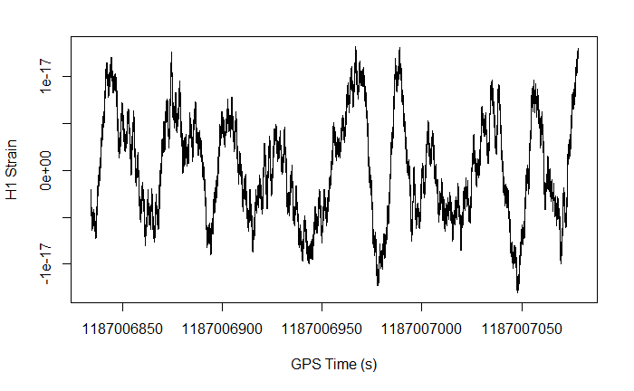

```r
plot(myTime[0:numSamples], strain[0:numSamples], type = "l", xlab = "GPS Time (s)", ylab = "H1 Strain")
```